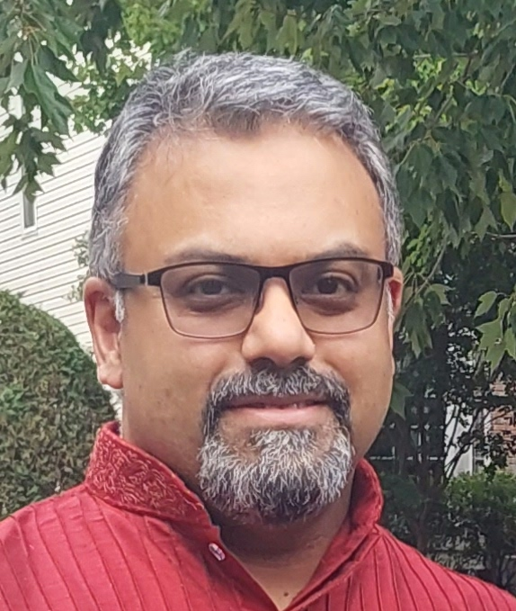

# Abhijit Das Gupta

[Twitter/X](https://twitter.com/webbedfeet) [Bluesky](https://bsky.app/profile/webbedfeet.bsky.social) [Public Github](https://github.com/webbedfeet) [LinkedIn](https://www.linkedin.com/in/abhijit-dasgupta-70197713/)

Abhijit Das Gupta is a *Data Science Director* at AstraZeneca. He works at the interface of statistics and machine learning, with broad experience in statistical modeling and machine learning, bioinformatics, optimization, signal processing, and data visualization. He holds a PhD in Biostatistics with earlier training in Mathematical Statistics. He has been using R for over 25 years for a wide variety of applications in biomedical research, as well as for data-driven reports and presentations.

Abhijit is adjunct faculty at **Georgetown University**, where he currently teaches courses in Data Visualization and Big Data & Cloud Computing and is a mentor to the Capstone project within the MS in Data Science program, as well as teaching introductory Data Science for the MS in Environment and International Affairs program. He is also adjunct faculty at George Mason University where he guest lectures twice a year. He is a certified [Carpentries](http://www.carpentries.org) instructor. He co-founded and organized the [Statistical Programming DC](http://www.meetup.com/stats-prog-dc) meetup (formerly R Users Group DC) for several years and got to know several luminaries in the field, including DJ Patil, Hadley Wickham, Max Kuhn, Frank Harrell and others.

Outside of work, Abhijit is an aikido instructor holding a 5th degree black belt, having practiced the art since 1994. He teaches in Frederick County, MD. He is also active in community theater productions with [Ebong Theatrix](https://www.ebongtheatrix.org), a Bengali theater group in the DC area.